# Sample data analysis using R report

Martín Lotto Batista

2023-07-04

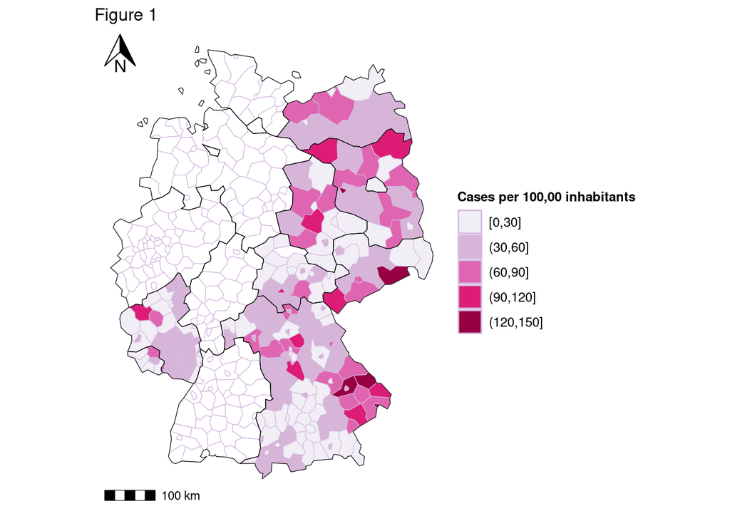

#### Introduction

This report utilizes data from the German surveillance system, which is publicly available on the online platform Survstat@RKI maintained by the [Robert Koch Institute](https://survstat.rki.de/). The data used in this analysis includes weekly case counts of Lyme disease reported in 2021, stratified by NUTS-3 district, age group and binary sex classification. Population size data for the corresponding year were extracted from the German Statistics Office (Destatis) For the purpose of this report, cases without spatial allocation or with unknown age or sex designation were excluded. In this document, a brief description of the data will be provided using summary statistics, classic visualization techniques, and a basic exploratory analysis.

#### Lyme disease cases in Germany in 2021

In 2021, a total of 10,841 Lyme disease cases were reported to the German surveillance system. The overall average annual incidence rate was 13.02 cases per 100,000 inhabitants. The districts with the highest annual incidence rates per 100,000 inhabitants were Straubing-Bogen, Pasau, Regen and Freyung-Grafenay in Bavaria, as well as Bandenburg city located in the state of Brandenburg (Figure 1).

Table 1

| Age group | Females | Males |
| --- | --- | --- |
| [00-10) | 444 (7.31%) | 465 (9.75%) |
| [10-20) | 231 (3.8%) | 226 (4.74%) |
| [20-30) | 266 (4.38%) | 253 (5.3%) |
| [30-40) | 512 (8.43%) | 486 (10.19%) |
| [40-50) | 656 (10.81%) | 602 (12.62%) |
| [50-60) | 1297 (21.36%) | 969 (20.31%) |
| [60-75) | 1955 (32.2%) | 1315 (27.57%) |
| [75+) | 710 (11.69%) | 454 (9.52%) |

To assess the general spatial structure in the data, the Global Moran’s I statistic was used. The results indicate that the spatial distribution of incidence among districts is random (Moran’s I: -0.009, p-value: 0.522).

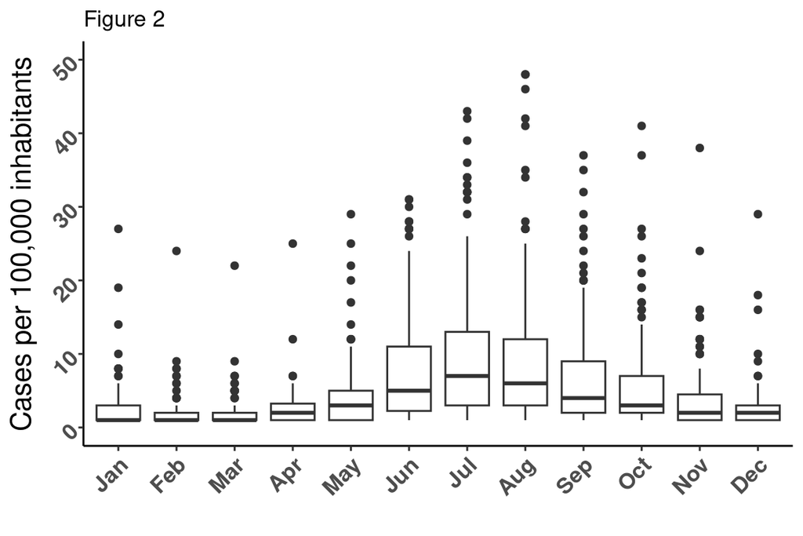

To evaluate the association between age groups, sex and the occurrence of Lyme disease, a generalized linear model (GLM) was employed. Given the overdispersion in the data, the response was assumed to follow a negative binomial distribution. Based on the results, after accounting for the role of age, the risk of Lyme disease was higher in females than in males, with a relative risk (RR) for males of 0.9 (CI: 0.84-0.96). Likewise, after considering the effect of sex, the highest risk was observed in the 60-75 age group, with a RR of 1.14 (CI: 1.01-1.29), while the lowest risk in the 10-20 and 20-30 age groups, with RRs of 0.56 (CI: 0.48-0.66) and 0.59 (CI: 0.50-0.69), respectively (Figure 3).

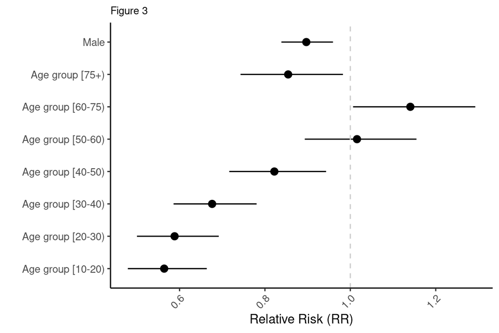

#### Conclusion

All the Federal States in Germany with ongoing Lyme disease surveillance reported cases cases to the national surveillance system. The highest incidence was found in Bavaria and Brandenburg states, and there were signs of a random spatial distribution of cases. The risk of disease was higher in females than in males, as well as in adults between 60 and 75 years old.